# act_report

## Descriptive and Visual Analysis

Once I had completed my assessment of the data and fixed all the issues within my data set, I was left with two clean and tidy data sets, one on tweet data and one on tweet images.

The requireents of the project was generate insights and to create visualizations from the data. A similar approach to the analysis part was used i.e a question was asked with hopes of finding an answer with the visualization.

Insight 1:

Which rating was the most popular?

Using visualization; seaborn's barplot, it beecomes evidently clear that rating of 12 was more populare than any other rating as seen in the iomage below;

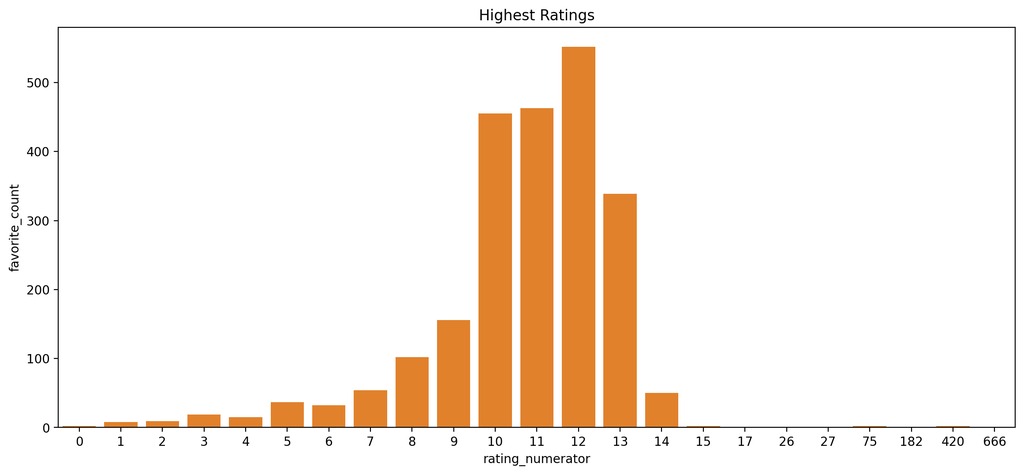

Barchart showing counts of the different ratings.

Insight 2: Most popular dog stages.

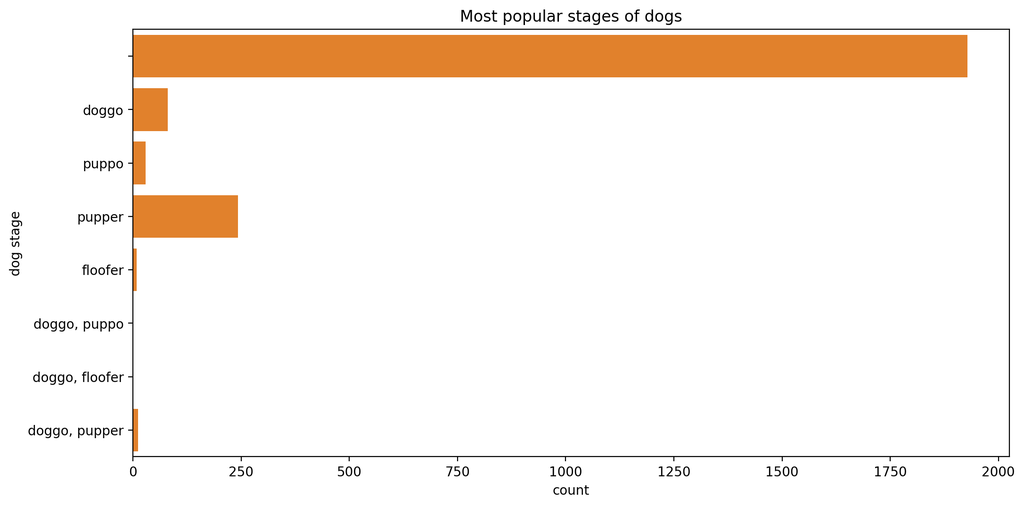

Horizontal bar chart showing most popular dog stages

Insight 3: Relationship Between Rating and Average Favorite Count. Analysing the data, it was observed that there were ratings above 10 and some ratings below 10. To understand the relationship between rating and favorite counts, the average favorite counts for ratings above 10 was determined (using the groupby and mean functions of pandas). Same was done for ratings below 10. A bar chart was created to visualise the findings which show that ratings above 10 had more favorite counts than ratings below 10 on average. This is depicted below:

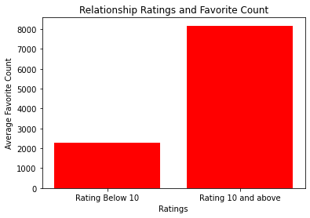

Barchart showing the relationship between average favorite counts and ratings.

Further visualisations were carried out on the data set just to show how favorite and retweet counts incereased/decreased over time. Two scatterplots were created to show this relationship and are shown below.

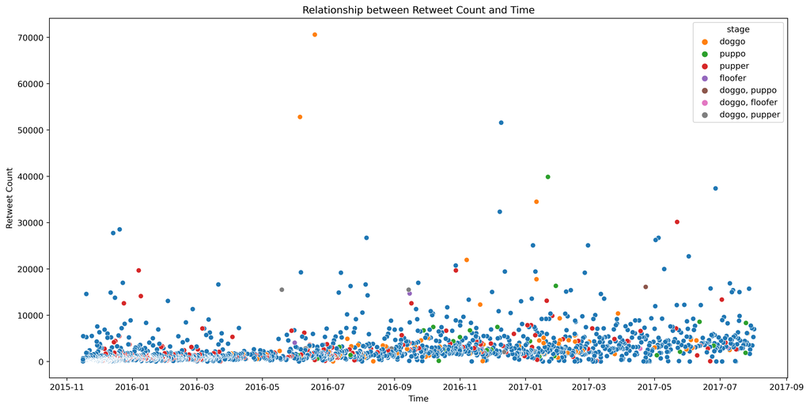

How retweet counts fared over time

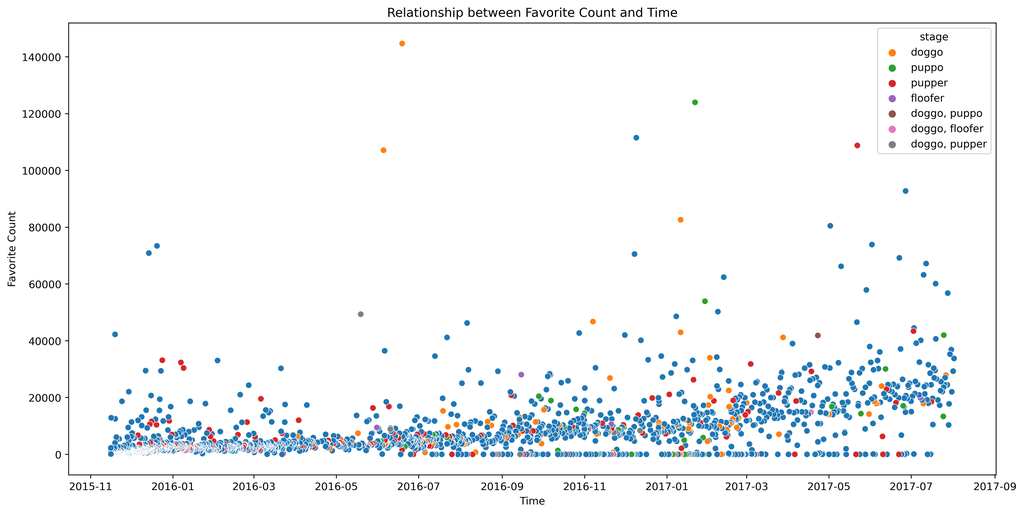

How favorite counts fared over time

Conclusion The importance of visually checking the data can not be over emphasized. For a lot of people, checking or looking at data manually is the task they struggle with. However, it was only when I looked at the actual data and not an abstract version of it did I find some of the faults in it. It also helped me become an expert at my data set so by the time I moved my analysis, I knew my data set inside out, which is highly recommended by expert data analysts. The data wrangling project was really fun to work with. It is always fun to sit down with a data set and try to gauge what it is telling you. Along with the fun bit, there was also quite a bit of learning in this project.